# Predictive Analytics Exam Case

Associate Professor Ole Maneesoonthorn

Term 4 2020

## The Context

The file “CreditBal.RData” contains data on the credit card balance ratio for 400 credit card accounts. The dataframe contains eight variables:

1. Income = account holder’s income recorded in thousands of dollars.
2. Rating = account holder’s credit score at the time of credit approval. Larger score implies better credit and lower chance of a default (as assessed by the bank).
3. Age = account holder’s age in years.
4. Education = number of years of education reported by account holder.
5. Gender = male/female records identifying account holder’s gender.
6. Student = yes/no records to indicate whether the account holder is a student.
7. Married = yes/no records to indicate whether the account holder is legally married.
8. Balance = numeric representing the percentage of credit card limit outstanding as unpaid balance. For example, a balance value of 10 means that 10% of the card limit is left as unpaid balance at the time of data collection.

The objective of this case is to construct a predictive model for the balance ratio. These predictions help the financial institutions particularly with risk projections related to the expected loss resulting from credit defaults since credit card is a type of unsecured loans.

The remainder of the document contains the various predictive models that we explored in Predictive Analytics throughout the term. Use these results to answer the exam questions.

### Data & functions

```r
#Defining a function to compute the all metrics for cross sectional data
#Packages available to compute the metrics, but this function conveniently gathers all metrics
csaccuracy<-function(actual,predicted,naive){
  stats<-matrix(0,1,4)
  colnames(stats)<-c("RMSE","MAE","MAPE","MASE")
  dev<-actual-predicted
  BE=mean(abs(actual-naive))
  q=(dev)/BE
  stats[1]=sqrt(mean(dev^2))
  stats[2]=mean(abs(dev))
  stats[3]=mean(100*abs(dev/actual))
  stats[4]=mean(abs(q))
  return(stats)
}

#Loading in the data and sample split
load("CreditBal.RData")
set.seed(123)
train_index <- sample(1:nrow(Credit), 0.8 * nrow(Credit))
train=Credit[train_index,]
test=Credit[-train_index,]
```

### Linear regression

Predictive assessment of linear regression:

```r
#Predictive assessment with linear regression
fitlm=lm(Balance~.,data=train)
summary(fitlm)
```

```
##
## Call:
## lm(formula = Balance ~ ., data = train)
##
## Residuals:
##     Min      1Q  Median      3Q     Max
## -8.1215 -1.0900  0.4026  1.2480  5.5159
##
## Coefficients:
##               Estimate Std. Error t value Pr(>|t|)
## (Intercept)  -3.424943   0.657205  -5.211 3.42e-07 ***
## Income       -0.189649   0.004954 -38.281  < 2e-16 ***
## Rating        0.061096   0.001128  54.170  < 2e-16 ***
## Age          -0.014188   0.006264  -2.265   0.0242 *
## Education    -0.047555   0.034000  -1.399   0.1629
## GenderFemale -0.129364   0.211026  -0.613   0.5403
## StudentYes    9.308102   0.334871  27.796  < 2e-16 ***
## MarriedYes   -0.216562   0.219005  -0.989   0.3235
## ---
## Signif. codes:  0 '***' 0.001 '**' 0.01 '*' 0.05 '.' 0.1 ' ' 1
##
## Residual standard error: 1.884 on 312 degrees of freedom
## Multiple R-squared:  0.9227, Adjusted R-squared:  0.9209
## F-statistic: 531.7 on 7 and 312 DF,  p-value: < 2.2e-16
```

```r
predlm=predict(fitlm,newdata=test)
stats1=csaccuracy(test$Balance,predlm,mean(train$Balance))
stats1
```

```
##          RMSE      MAE MAPE     MASE
## [1,] 1.818257 1.378134  Inf 0.227253
```

### Regression tree

Predictive assessment of the regression tree:

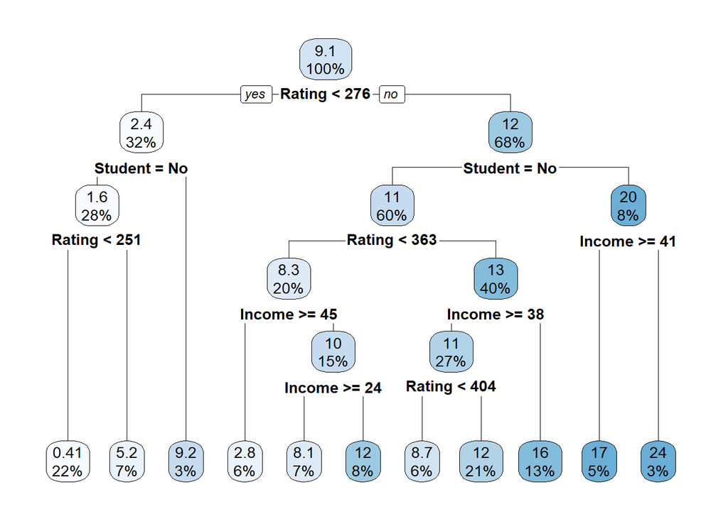

```r
# Load the libraries
# Note rpart.plot enables us to plot the tree visually
library(rpart)
library(rpart.plot)
library(vip)

# Building model
regtree <- rpart(formula = Balance ~ ., data = train, method  = "anova",
                 control=rpart.control(cp=0.01))

# Visualizing the tree
rpart.plot(regtree)
```

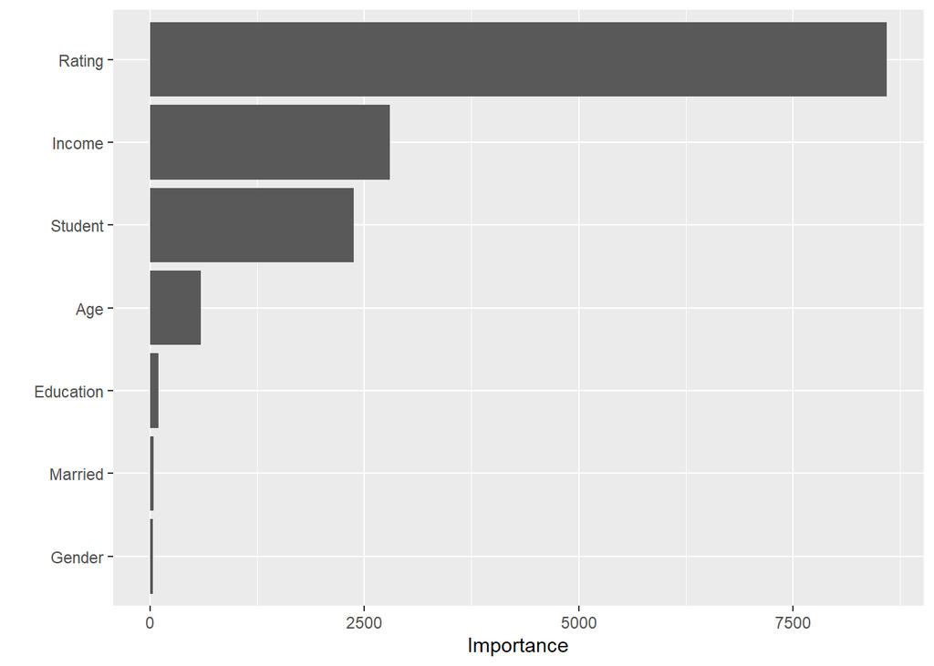

```r
#Variable importance from the tree algorithm
vip(regtree)
```

```r
# prediction
y_regtree<- predict(regtree, newdata = test)
stats2=csaccuracy(test$Balance,y_regtree,mean(train$Balance))
stats2
```

```
##          RMSE     MAE MAPE      MASE
## [1,] 2.391062 1.73136  Inf 0.2854997
```

### Neural network

Predictive assessment of the neural network:

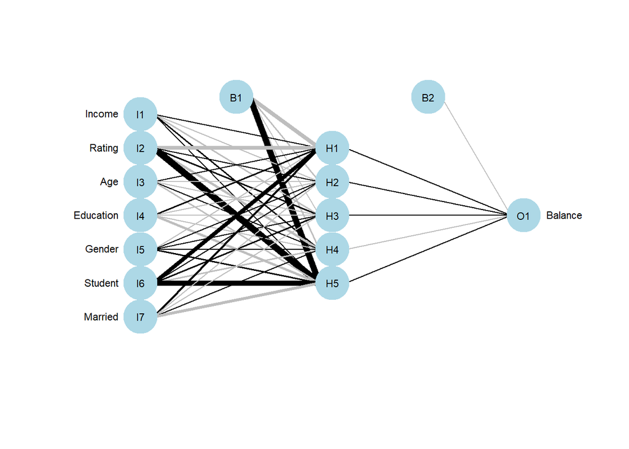

```r
library(neuralnet)
# Convert categorical variables to dummy variables 0/1 coding
# For the usage of model which do not accept factor variables
catVar <- model.matrix(~Gender+Student+Married, data = Credit)[,-1]
dat_scaled=Credit
dat_scaled[,5:7]=catVar
which=c(1:4,8)
for(i in 1:length(which)){
  dat_scaled[,which[i]]=as.numeric(scale(Credit[,which[i]]))
}
train_scaled=dat_scaled[train_index,]
test_scaled=dat_scaled[-train_index,]
set.seed(321)
NN <- neuralnet(formula = Balance ~., data=train_scaled, hidden = 5)

#Visualization of the neural network
library(NeuralNetTools)
plotnet(NN,cex_val=0.7)
```

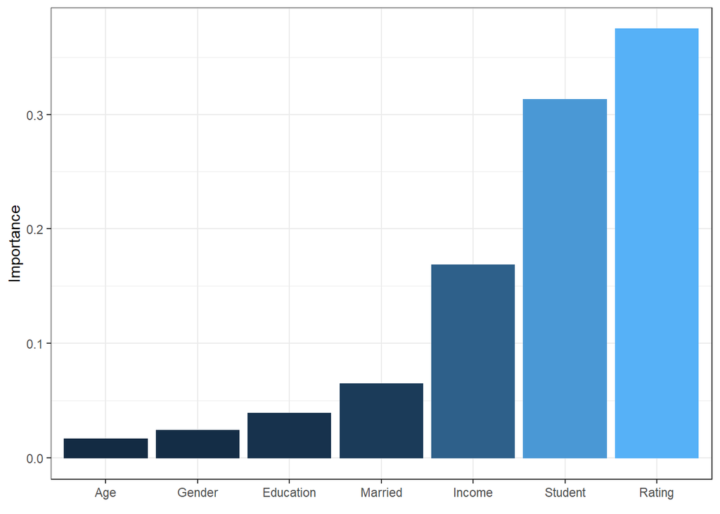

```r
#variable importance
#two different methods to look at them
garson(NN)
```

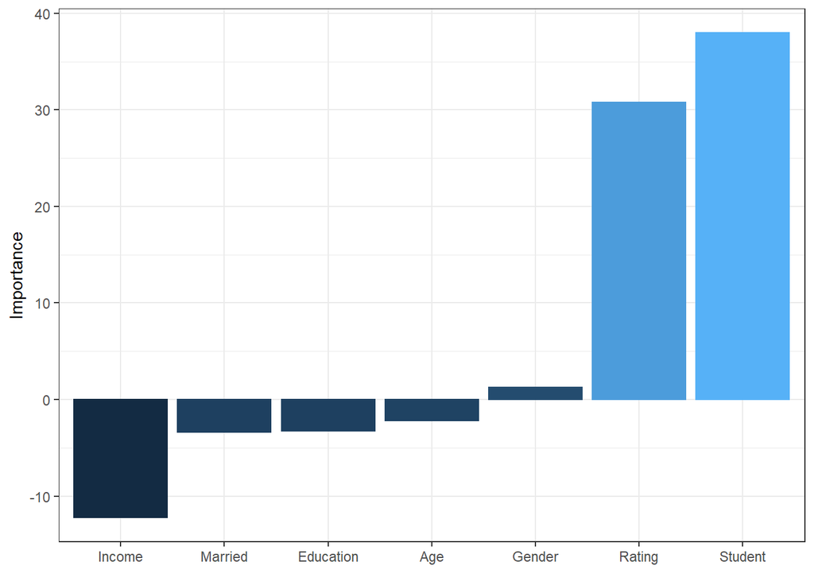

```r
olden(NN)
```

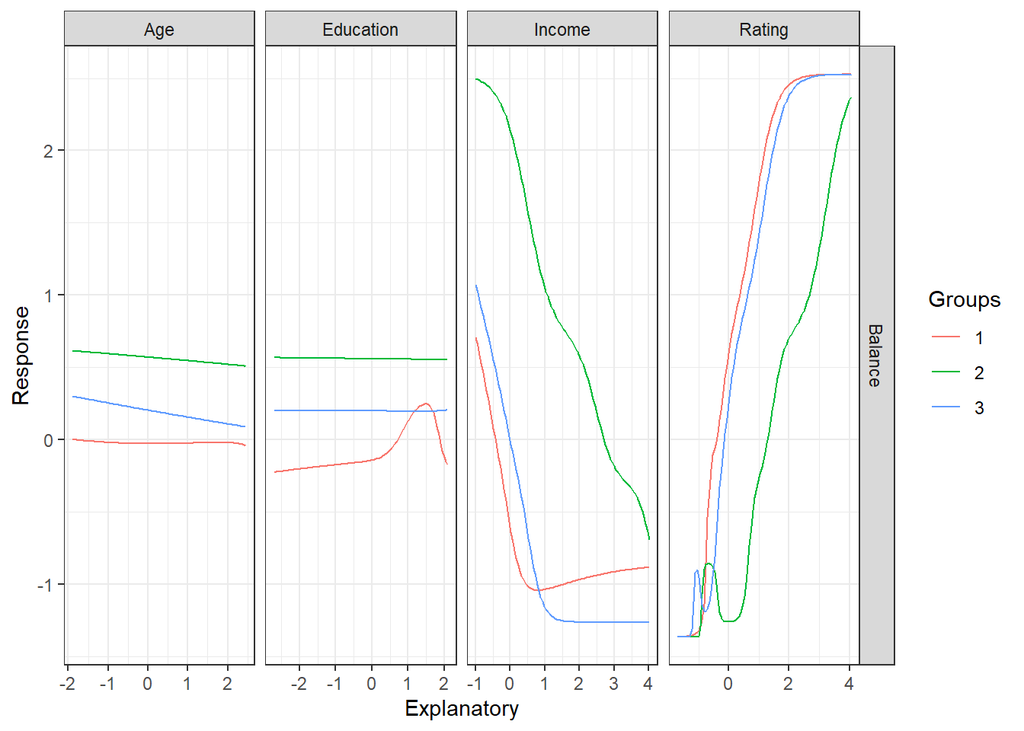

```r
#by clusters - group data into 3 clusters
set.seed(321)
lekprofile(NN,xsel=c('Income','Rating','Age','Education'),group_val=3)
```

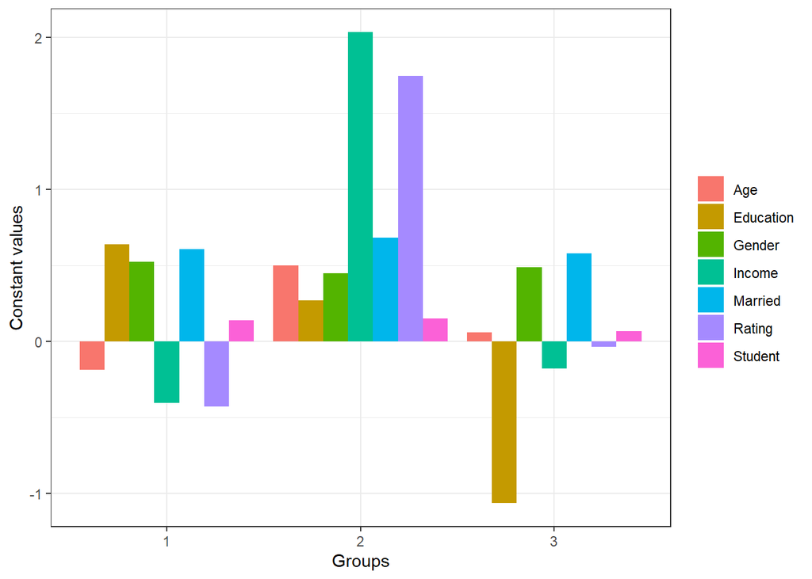

```r
#Reveal the characteristics of the clusters
set.seed(321)
lekprofile(NN,xsel=c('Income','Rating','Age','Education'),group_val=3,group_show=TRUE)
```

```r
#Predicting with neural network
y_NN <- predict(NN, newdata = test_scaled)

# convert predicted y into  original unit
y_NN <- y_NN*sd(train[,"Balance"]) + mean(train[,"Balance"])
head(y_NN)
```

```
##          [,1]
## 1  10.5766127
## 3   8.1488569
## 6  14.0786238
## 15  7.4243666
## 17  0.4063292
## 18  9.2747716
```

```r
stats3=csaccuracy(test$Balance,y_NN,mean(train$Balance))
stats3
```

```
##           RMSE       MAE MAPE      MASE
## [1,] 0.9461103 0.7035079  Inf 0.1160078
```

### K-Nearest neighbour regression

Predictive assessment of K-NN:

```r
#Loading the library
library(caret)
#Let's look at how well the knn regression fits the training data - use scaled data here
#Remember you need to remove the output variable to train k-nn (unsupervised)
knn_fit <- knnreg(x = train_scaled[, -8] , y = train_scaled[,"Balance"] ,
                  k = as.integer(sqrt(nrow(train))))

#Don't forget to convert the predictions back to raw data unit when obtaining predictions
y_knnm <- predict(knn_fit,test_scaled[,-8])
y_knnm<-y_knnm*sd(train[,"Balance"])+mean(train[,"Balance"])
stats4=csaccuracy(test$Balance,y_knnm,mean(train$Balance))
stats4
```

```
##          RMSE      MAE MAPE      MASE
## [1,] 4.245304 3.397074  Inf 0.5601744
```

### Bagging

Predictive assessment of the bagging:

```r
# Bagging
set.seed(1234)
# Training the bagging algorithm
bag <- train(Balance~., data = train, method='treebag')
print(bag)
```

```
## Bagged CART
##
## 320 samples
##   7 predictor
##
## No pre-processing
## Resampling: Bootstrapped (25 reps)
## Summary of sample sizes: 320, 320, 320, 320, 320, 320, ...
## Resampling results:
##
##   RMSE      Rsquared   MAE
##   2.834316  0.8182493  1.957473
```

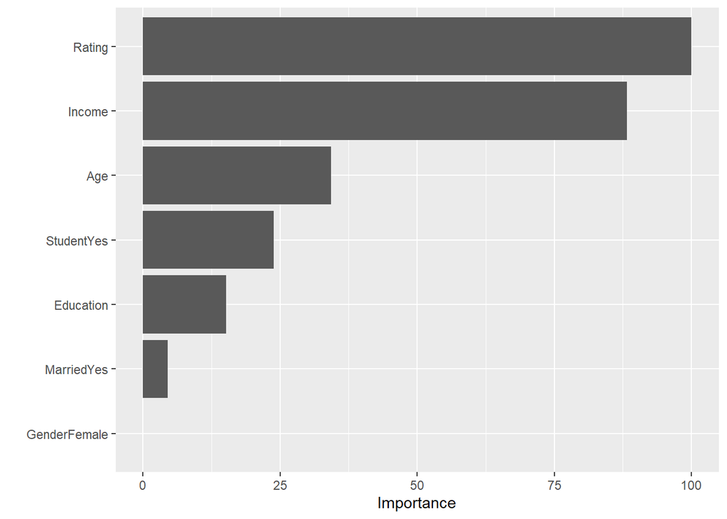

```r
# Plotting variable importance from the algorithm
vip(bag)
```

```r
# Predicting test data using trained bag
y_bag <- predict(bag, newdata = test)
stats5=csaccuracy(test$Balance,y_bag,mean(train$Balance))
stats5
```

```
##          RMSE      MAE MAPE     MASE
## [1,] 2.199081 1.611695  Inf 0.265767
```

### Random forest

Predictive assessment of random forest:

```r
# Load randomForest library
library(randomForest)
# Set random seet to make sure results remain static
set.seed(1234)
randFor = randomForest(Balance ~ ., data = train, importance = TRUE,
                        mtry=3)
print(randFor)
```

```
##
## Call:
##  randomForest(formula = Balance ~ ., data = train, importance = TRUE,      mtry = 3)
##                Type of random forest: regression
##                      Number of trees: 500
## No. of variables tried at each split: 3
##
##           Mean of squared residuals: 4.775322
##                     % Var explained: 89.33
```

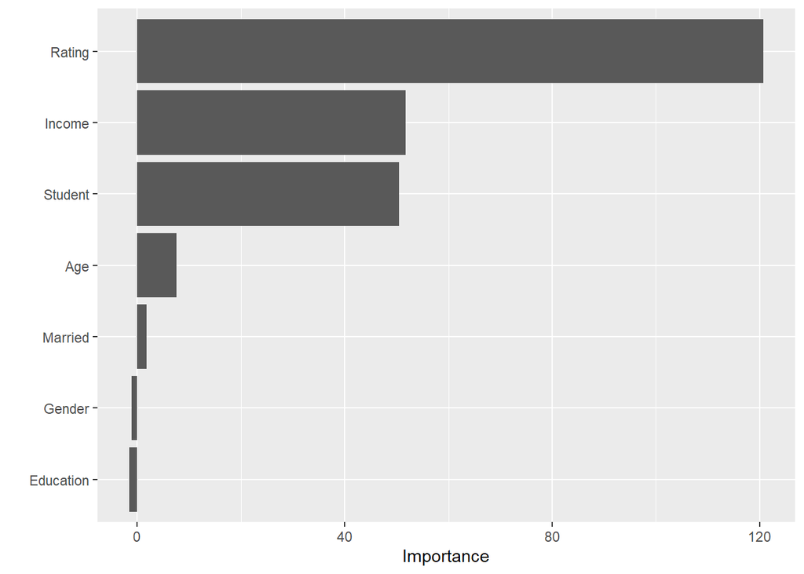

```r
# Plot variable importance
vip(randFor)
```

```r
# Predicting test data using trained forest
y_rf<- predict(randFor, newdata = test)
stats6=csaccuracy(test$Balance,y_rf,mean(train$Balance))
stats6
```

```
##         RMSE      MAE MAPE      MASE
## [1,] 2.06789 1.522923  Inf 0.2511287
```

### Boosting

Predictive assessment of boosting:

```r
#Load the mboost library
library(mboost)
#Set random seed and train the boosting algorithm
set.seed(1234)
boost <- glmboost(Balance~., data = train,
                  control=boost_control(nu=0.3))
summary(boost)
```

```
##
##   Generalized Linear Models Fitted via Gradient Boosting
##
## Call:
## glmboost.formula(formula = Balance ~ ., data = train, control = boost_control(nu = 0.3))
##
##
##   Squared Error (Regression)
##
## Loss function: (y - f)^2
##
##
## Number of boosting iterations: mstop = 100
## Step size:  0.3
## Offset:  9.143159
##
## Coefficients:
##  (Intercept)       Income       Rating          Age    Education   StudentYes
## -12.69110809  -0.17899878   0.05845799  -0.01150245  -0.02442502   9.00323772
##   MarriedYes
##  -0.07765351
## attr(,"offset")
## [1] 9.143159
##
## Selection frequencies:
##     Rating     Income StudentYes        Age  Education MarriedYes
##       0.43       0.40       0.11       0.03       0.02       0.01
```

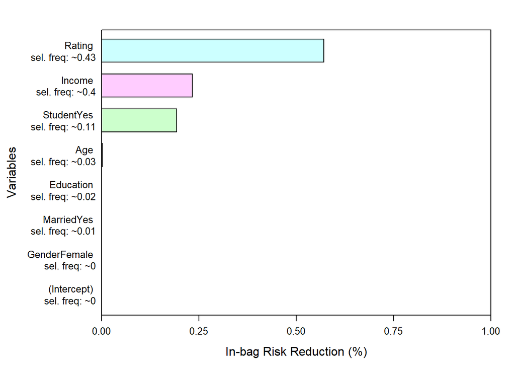

```r
#Variable importance plot - mboost library has its own function
plot(varimp(boost))
```

```r
# Predicting test data using the trained boosting algorithm
y_boost <- predict(boost, newdata = test)
stats7=csaccuracy(test$Balance,y_boost,mean(train$Balance))
stats7
```

```
##          RMSE      MAE MAPE      MASE
## [1,] 1.884219 1.406236  Inf 0.2318871
```

### Support vector machine

Predictive assessment of support vector machine:

```r
# load the svm library
library(e1071)
svmm <- svm(Balance~., data=train, kernel = "linear")
svmm
```

```
##
## Call:
## svm(formula = Balance ~ ., data = train, kernel = "linear")
##
##
## Parameters:
##    SVM-Type:  eps-regression
##  SVM-Kernel:  linear
##        cost:  1
##       gamma:  0.125
##     epsilon:  0.1
##
##
## Number of Support Vectors:  213
```

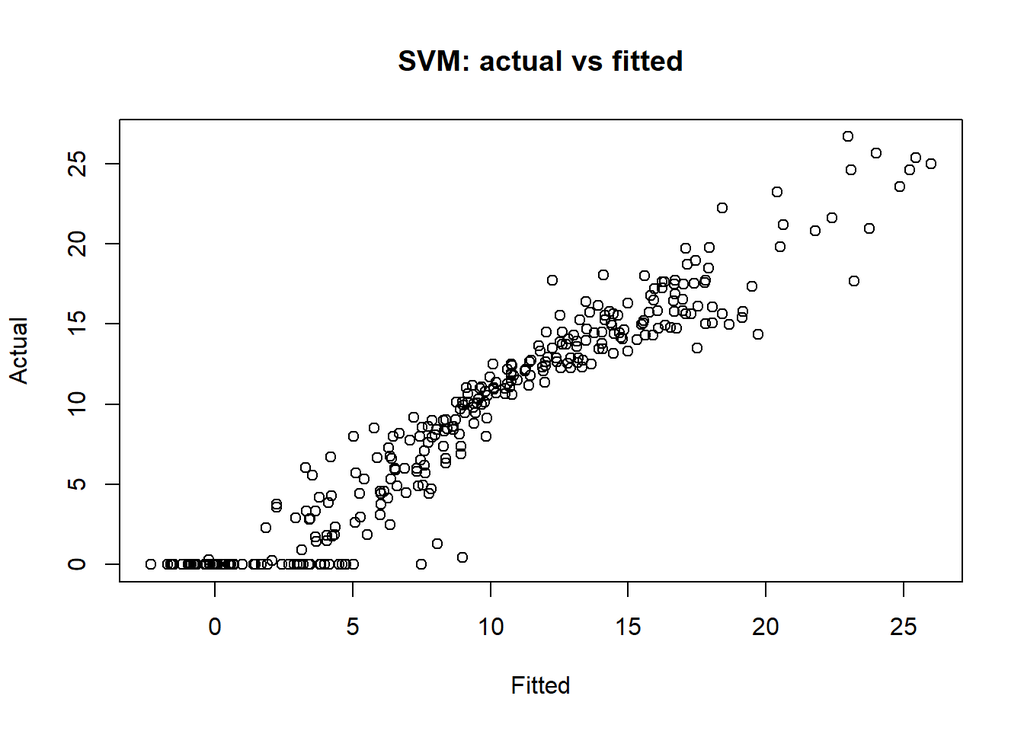

```r
#plotting svm fitted values against actual data
plot(x=svmm$fitted,y=train[,"Balance"],
     xlab="Fitted", ylab="Actual", main="SVM: actual vs fitted")
```

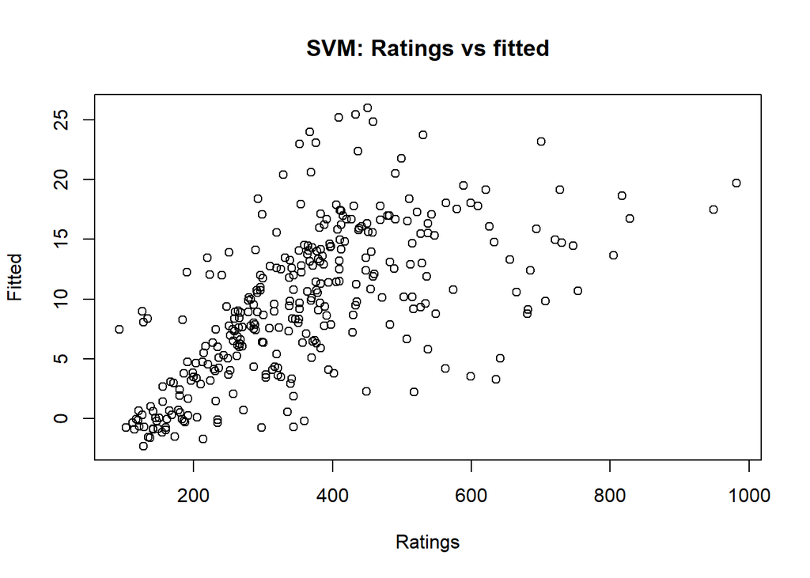

```r
#plotting svm fitted values against actual data
plot(x=train$Rating,y=svmm$fitted,
     xlab="Ratings", ylab="Fitted", main="SVM: Ratings vs fitted")
```

```r
# Predict the test data using trained svm
y_svmm <- predict(svmm, newdata=test)
stats8=csaccuracy(test$Balance,y_svmm,mean(train$Balance))
stats8
```

```
##          RMSE      MAE MAPE      MASE
## [1,] 1.898357 1.440989  Inf 0.2376178
```

### Summarizing the statistics

Collecting all predictive statistics:

```r
allstats=rbind(stats1,stats2,stats3,stats4,
               stats5,stats6,stats7,stats8)
rownames(allstats)=c("Linear Regression","RegTree","NeuralNetwork",
                     "k-NNReg","Bagging","RandomForest",
                     "Boosting","SVM")
allstats
```

```
##                        RMSE       MAE MAPE      MASE
## Linear Regression 1.8182569 1.3781337  Inf 0.2272530
## RegTree           2.3910620 1.7313599  Inf 0.2854997
## NeuralNetwork     0.9461103 0.7035079  Inf 0.1160078
## k-NNReg           4.2453042 3.3970736  Inf 0.5601744
## Bagging           2.1990810 1.6116947  Inf 0.2657670
## RandomForest      2.0678899 1.5229231  Inf 0.2511287
## Boosting          1.8842187 1.4062363  Inf 0.2318871
## SVM               1.8983568 1.4409891  Inf 0.2376178
```